# End-to-End Machine Learning Workflow for Predicting Cardiovascular Disease: Development and Evaluation

DA5030

Saval, Varshitha

04/10/2025

# Goals of the project:

The goal of this project is to predict the likelihood of an individual developing cardiovascular disease based on various health and lifestyle features.

This prediction is made using three machine learning models: 1)Logistic Regression, 2)Random Forest, and 3)xgboost.

The dataset used for this project is from Kaggle and contains a variety of health indicators, including age, cholesterol, blood pressure, and smoking habits.

Data Source: The dataset is sourced from Kaggle under the project title “Cardiovascular Disease Prediction.”

reference : https://raw.githubusercontent.com/varshithasaval/cardio-vasular-dataset/refs/heads/main/cardio_train.csv

Data Description: This dataset contains several features such as age, gender, blood pressure, cholesterol levels, smoking habits, alcohol consumption, and physical activity. The target variable is whether or not a person has cardiovascular disease (binary classification: 1 = disease, 0 = no disease).

Problem Type: This is a binary classification problem, where the goal is to predict whether an individual has cardiovascular disease based on the input features.

Real-World Application: Cardiovascular diseases (CVD) are one of the leading causes of death globally. Early detection through predictive models can help healthcare professionals focus resources on individuals at higher risk, potentially saving lives and reducing healthcare costs. The goal of this model is to provide a predictive tool for early intervention.

# load the required libraries

```r
library(knitr) #to generate dynamic documents
library(VIM)  # for visualizing and imputing missing values
library(randomForest)  # This library implements the Random Forest algorithm
library(caret)  # Classification And REgression Training
library(xgboost)  # xgboost for xgboost model
library(pROC)   # (ROC) curves
library(Metrics) # for calculating common model evaluation metrics
library(MLmetrics) # for learning metrics, including accuracy, precision, recall, F1-score, and AUC
```

In this section, we load the dataset that will be used for our cardiovascular disease prediction project. The dataset is loaded from a CSV file located at the specified URL. After loading the data, we preview the first few rows to get an understanding of the structure and contents of the dataset.

# Data loading and Data Overview

```r
# Data loading
url_cardio <- "https://raw.githubusercontent.com/varshithasaval/cardio-vasular-dataset/refs/heads/main/cardio_train.csv"

df_cardio <- read.csv(url_cardio, sep = ";")
hd <- head(df_cardio)
str <- str(df_cardio)
```

```
'data.frame':   70000 obs. of  13 variables:
 $ id         : int  0 1 2 3 4 8 9 12 13 14 ...
 $ age        : int  18393 20228 18857 17623 17474 21914 22113 22584 17668 19834 ...
 $ gender     : int  2 1 1 2 1 1 1 2 1 1 ...
 $ height     : int  168 156 165 169 156 151 157 178 158 164 ...
 $ weight     : num  62 85 64 82 56 67 93 95 71 68 ...
 $ ap_hi      : int  110 140 130 150 100 120 130 130 110 110 ...
 $ ap_lo      : int  80 90 70 100 60 80 80 90 70 60 ...
 $ cholesterol: int  1 3 3 1 1 2 3 3 1 1 ...
 $ gluc       : int  1 1 1 1 1 2 1 3 1 1 ...
 $ smoke      : int  0 0 0 0 0 0 0 0 0 0 ...
 $ alco       : int  0 0 0 0 0 0 0 0 0 0 ...
 $ active     : int  1 1 0 1 0 0 1 1 1 0 ...
 $ cardio     : int  0 1 1 1 0 0 0 1 0 0 ...
```

Understanding the Data The dataset contains 70,000 records with 13 features:

id: Unique record identifier.

age: Age in days.

gender: 1 = Male, 2 = Female.

height: Height in cm.

weight: Weight in kg.

ap_hi: Systolic blood pressure.

ap_lo: Diastolic blood pressure.

cholesterol: 1 = Normal, 2 = Above normal, 3 = Well above normal.

gluc: 1 = Normal, 2 = Above normal, 3 = Well above normal.

smoke: 0 = No, 1 = Yes.

alco: 0 = No, 1 = Yes.

active: 0 = No, 1 = Yes.

cardio: Target variable (0 = No, 1 = Yes).

The objective is to predict the likelihood of cardiovascular disease based on these features.

# Data Cleaning and Finding the missing values

```r
# checking with the columns for missing values
colSums(is.na(df_cardio))
```

```
         id         age      gender      height      weight
          0           0           0           0           0
      ap_hi       ap_lo cholesterol        gluc       smoke
          0           0           0           0           0
       alco      active      cardio
          0           0           0
```

# Simulating Missing Values

Although the dataset does not have any missing values, we simulate missing data for the ap_hi (systolic blood pressure) and ap_lo (diastolic blood pressure) columns. These columns are numeric and are crucial features that affect the target variable, cardio (presence of cardiovascular disease). By introducing missing values in these columns, we can observe how imputation and model performance are impacted.

The following code randomly introduces missing values in the ap_hi and ap_lo columns by selecting a random number of rows (between 10 and 40) and setting their values to NA. We will later handle these missing values through imputation. `

```r
data <- df_cardio

# Simulate missing values in ap_hi and ap_lo below 30
set.seed(123)

# Columns to introduce missing values
cols_to_remove <- c("ap_hi", "ap_lo")

# Loop through each column and simulate missing data (only values < 30)
for (col in cols_to_remove) {
  # Identify rows where values are below 30
  idx_below_30 <- which(data[[col]] < 30)

  # Randomly choose how many values to remove from those below 30
  n_missing <- sample(10:40, 1)  # randomly chooses how many values to remove
  missing_idx <- sample(idx_below_30, size = n_missing)

  # Set the selected rows to NA
  data[[col]][missing_idx] <- NA
}

# Check how many NA values are in each column
cols_na <- colSums(is.na(data))
print(cols_na)
```

```
         id         age      gender      height      weight
          0           0           0           0           0
      ap_hi       ap_lo cholesterol        gluc       smoke
         40          21           0           0           0
       alco      active      cardio
          0           0           0
```

# Imputing the missing values

I selected k-Nearest Neighbors (kNN) for imputing missing values because it effectively handles numerical data by using similar data points to predict missing values.

Since the missing data in this dataset (blood pressure values ap_hi and ap_lo) are numeric and correlated with other features, kNN is a suitable method. Unlike simpler techniques (e.g., mean or median imputation), kNN respects the relationships between data points and provides more accurate imputations.

[figure not shown]

# Outliers

Outlier Detection and Removal To improve model performance and reduce noise, I identified and removed outliers using Z-score normalization.

Outliers were defined as values with a Z-score > 3 or < -3. I iteratively removed rows containing such values until no extreme outliers remained.

This ensures the dataset is cleaner and less influenced by anomalous data points, especially for numeric variables like blood pressure and weight that directly impact the target variable.

```r
cor(df_imputed)
```

[output not shown]

[output cut: 13 more lines]

[output not shown]

# Feature Engineering

Feature engineering was performed to create new variables that provide more meaningful and relevant information for the model. By calculating BMI, pulse pressure, and converting age to years, the model can better understand relationships and patterns in the data, leading to improved performance and more accurate predictions.

```r
# BMI = weight (kg) / height (m)^2
df_imputed$BMI <- df_imputed$weight / ((df_imputed$height / 100)^2)

# Pulse pressure = systolic (ap_hi) - Diastolic (ap_lo)
df_imputed$pulse_pressure <- df_imputed$ap_hi - df_imputed$ap_lo

# Convert age from days to years
df_imputed$age_years <- df_imputed$age / 365

# View first few rows of updated data
head(df_imputed)
```

# Splitting the data into training and testing data set

```r
set.seed(123)

# Split data into training and testing sets (80% training, 20% testing)
sample_index <- sample(1:nrow(df_imputed), 0.8 * nrow(df_imputed), replace = FALSE)

# Create training and testing sets
training_set <- df_imputed[sample_index, ]
testing_set <- df_imputed[-sample_index, ]

# View first few rows of training and testing sets
knitr::kable(head(training_set))
```

|  | id | age | gender | height | weight | ap_hi | ap_lo | cholesterol | gluc | smoke | alco | active | cardio | BMI | pulse_pressure | age_years |
| --- | --- | --- | --- | --- | --- | --- | --- | --- | --- | --- | --- | --- | --- | --- | --- | --- |
| 54887 | 78302 | 23589 | 1 | 169 | 74 | 120 | 80 | 1 | 1 | 0 | 0 | 1 | 0 | 25.90946 | 40 | 64.62740 |
| 61526 | 87844 | 18759 | 2 | 168 | 93 | 140 | 80 | 3 | 1 | 1 | 0 | 1 | 1 | 32.95068 | 60 | 51.39452 |
| 3183 | 4488 | 16727 | 1 | 157 | 68 | 110 | 90 | 1 | 2 | 0 | 0 | 1 | 0 | 27.58733 | 20 | 45.82740 |
| 31815 | 45442 | 19011 | 1 | 158 | 90 | 130 | 70 | 1 | 3 | 0 | 0 | 0 | 0 | 36.05191 | 60 | 52.08493 |
| 66498 | 94931 | 20138 | 1 | 168 | 70 | 120 | 80 | 1 | 1 | 0 | 0 | 1 | 0 | 24.80159 | 40 | 55.17260 |
| 48263 | 68923 | 22005 | 1 | 155 | 62 | 140 | 90 | 2 | 2 | 0 | 0 | 1 | 1 | 25.80645 | 50 | 60.28767 |

```r
knitr::kable(head(testing_set))
```

|  | id | age | gender | height | weight | ap_hi | ap_lo | cholesterol | gluc | smoke | alco | active | cardio | BMI | pulse_pressure | age_years |
| --- | --- | --- | --- | --- | --- | --- | --- | --- | --- | --- | --- | --- | --- | --- | --- | --- |
| 1 | 0 | 18393 | 2 | 168 | 62 | 110 | 80 | 1 | 1 | 0 | 0 | 1 | 0 | 21.96712 | 30 | 50.39178 |
| 4 | 3 | 17623 | 2 | 169 | 82 | 150 | 100 | 1 | 1 | 0 | 0 | 1 | 1 | 28.71048 | 50 | 48.28219 |
| 9 | 13 | 17668 | 1 | 158 | 71 | 110 | 70 | 1 | 1 | 0 | 0 | 1 | 0 | 28.44095 | 40 | 48.40548 |
| 13 | 18 | 14791 | 2 | 165 | 60 | 120 | 80 | 1 | 1 | 0 | 0 | 0 | 0 | 22.03857 | 40 | 40.52329 |
| 15 | 23 | 14532 | 2 | 181 | 95 | 130 | 90 | 1 | 1 | 1 | 1 | 1 | 0 | 28.99789 | 40 | 39.81370 |
| 23 | 32 | 23046 | 1 | 158 | 90 | 145 | 85 | 2 | 2 | 0 | 0 | 1 | 1 | 36.05191 | 60 | 63.13973 |

```r
NA
NA
```

# Normalizing the data

```r
# Columns to normalize
cols_to_normalize <- c("age", "height", "weight", "ap_hi", "ap_lo", "BMI", "pulse_pressure")

# Normalize only the selected columns
df_imputed[cols_to_normalize] <- scale(df_imputed[cols_to_normalize])

normalized_df <- df_imputed


# View first few rows
knitr::kable(head(normalized_df))
```

| id | age | gender | height | weight | ap_hi | ap_lo | cholesterol | gluc | smoke | alco | active | cardio | BMI | pulse_pressure | age_years |
| --- | --- | --- | --- | --- | --- | --- | --- | --- | --- | --- | --- | --- | --- | --- | --- |
| 0 | -0.4305392 | 2 | 0.4787033 | -0.8786193 | -1.0428868 | -0.096745 | 1 | 1 | 0 | 0 | 1 | 0 | -1.0987357 | -1.3928614 | 50.39178 |
| 1 | 0.3128544 | 1 | -1.1009917 | 0.9296948 | 0.9654070 | 1.056536 | 3 | 1 | 0 | 0 | 1 | 1 | 1.6616664 | 0.4970671 | 55.41918 |
| 2 | -0.2425639 | 1 | 0.0837795 | -0.7213746 | 0.2959757 | -1.250026 | 3 | 1 | 0 | 0 | 0 | 1 | -0.7705932 | 1.4420313 | 51.66301 |
| 3 | -0.7424809 | 2 | 0.6103445 | 0.6938277 | 1.6348382 | 2.209816 | 1 | 1 | 0 | 0 | 1 | 1 | 0.3374973 | 0.4970671 | 48.28219 |
| 4 | -0.8028436 | 1 | -1.1009917 | -1.3503534 | -1.7123180 | -2.403306 | 1 | 1 | 0 | 0 | 0 | 0 | -0.8763675 | -0.4478971 | 47.87397 |
| 8 | 0.9958852 | 1 | -1.7591980 | -0.4855075 | -0.3734555 | -0.096745 | 2 | 2 | 0 | 0 | 0 | 0 | 0.4810910 | -0.4478971 | 60.03836 |

```r
NA
NA
```

# Logistic regression

Purpose: Target variable is cardio, which is a binary variable (either 0 or 1). Logistic regression is specifically designed for binary outcomes, making it a natural choice for problems where the target variable has two possible classes.

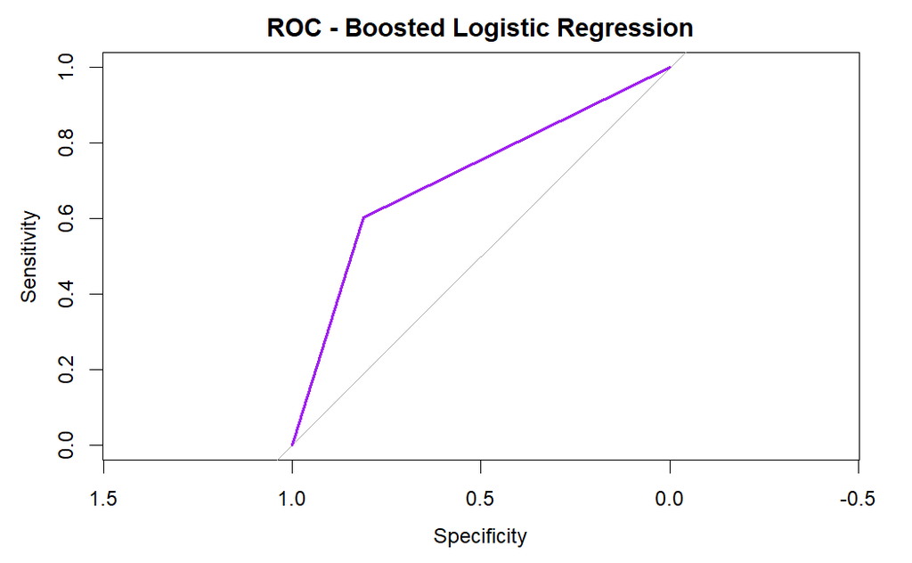

```r
# Logistic Regression with 5-fold cross-validation

log_training_set <- training_set
log_testing_set <- testing_set

# Ensure target is a factor
log_training_set$cardio <- factor(log_training_set$cardio, levels = c(0, 1), labels = c("No", "Yes"))
log_testing_set$cardio <- factor(log_testing_set$cardio, levels = c(0, 1), labels = c("No", "Yes"))

log_model <- train(factor(cardio) ~ .,
                   data = log_training_set,
                   method = "glm",
                   family = "binomial",
                   trControl = trainControl(method = "cv", number = 5, classProbs = TRUE, summaryFunction = twoClassSummary),
                   metric = "ROC"
)


# BOOSTED LOGISTIC REGRESSION (LogitBoost)

set.seed(123)
boosted_log_model <- train(
  cardio ~ .,
  data = log_training_set,
  method = "LogitBoost",
  trControl = trainControl(method = "cv", number = 5, classProbs = TRUE, summaryFunction = twoClassSummary),
  metric = "ROC",
  tuneLength = 10
)

boosted_log_preds <- predict(boosted_log_model, newdata = log_testing_set)
boosted_log_probs <- predict(boosted_log_model, newdata = log_testing_set, type = "prob")[, "Yes"]

cm_log <- confusionMatrix(boosted_log_preds, log_testing_set$cardio)
roc_boosted_log <- roc(response = log_testing_set$cardio, predictor = boosted_log_probs)
plot(roc_boosted_log, col = "purple", main = "ROC - Boosted Logistic Regression")
```

```r
NA
NA
NA
```

Used Logistic Regression with 5-fold cross-validation to predict cardiovascular disease (cardio). This method is effective for binary classification problems like this one, where the goal is to predict the presence or absence of a condition based on several features.

Kappa: 0.4455 – Indicates moderate agreement between predicted and actual values.

# Random forest

Random Forest would be a suitable choice for this dataset. It can handle complex, non-linear relationships between features like age, blood pressure, and weight, and is robust to outliers and missing values. Unlike simpler models, Random Forest uses multiple decision trees to improve predictive performance and reduce the risk of overfitting.

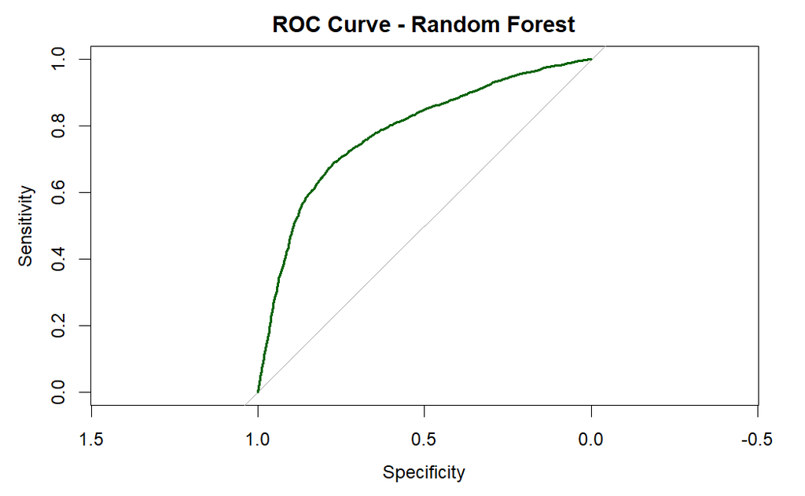

The kappa value of 0.46 suggests a moderate agreement between the model’s predictions and the actual outcomes beyond chance, and the very low p-value (< 2.2e-16) confirms that the model’s performance is statistically significant compared to random guessing.

# xgboost model

```r
cm_xg
```

```
Confusion Matrix and Statistics

          Reference
Prediction   No  Yes
       No  5303 2151
       Yes 1427 4292

               Accuracy : 0.7284
                 95% CI : (0.7207, 0.736)
    No Information Rate : 0.5109
    P-Value [Acc > NIR] : < 2.2e-16

                  Kappa : 0.4552

 Mcnemar's Test P-Value : < 2.2e-16

            Sensitivity : 0.7880
            Specificity : 0.6661
         Pos Pred Value : 0.7114
         Neg Pred Value : 0.7505
             Prevalence : 0.5109
         Detection Rate : 0.4026
   Detection Prevalence : 0.5659
      Balanced Accuracy : 0.7271

       'Positive' Class : No
```

XGBoost was chosen for this analysis because it handles complex, non-linear relationships effectively, which is crucial for predicting cardiovascular disease. Its boosting technique improves accuracy by combining multiple decision trees, and it is capable of managing large datasets, missing values, and providing insights into feature importance. This makes XGBoost an efficient and powerful choice for such classification tasks.

# Ensemble and Evaluations of models

*weighted voting ensembling*

Weighted voting ensembling improves prediction accuracy by combining multiple models and giving more importance to the better-performing ones. It leverages the strengths of each model, handles class imbalances, reduces overfitting, and optimizes overall performance.

```r
cm_ensemble
```

```
Confusion Matrix and Statistics

          Reference
Prediction   No  Yes
       No  5385 2268
       Yes 1345 4175

               Accuracy : 0.7257
                 95% CI : (0.718, 0.7333)
    No Information Rate : 0.5109
    P-Value [Acc > NIR] : < 2.2e-16

                  Kappa : 0.4495

 Mcnemar's Test P-Value : < 2.2e-16

            Sensitivity : 0.8001
            Specificity : 0.6480
         Pos Pred Value : 0.7036
         Neg Pred Value : 0.7563
             Prevalence : 0.5109
         Detection Rate : 0.4088
   Detection Prevalence : 0.5810
      Balanced Accuracy : 0.7241

       'Positive' Class : No
```

# Comaparision of logistic, random forest and xgboost models with ensemble

This step helps in making an informed, data-driven choice of the best-performing model.

```r
# F1 scores
f1_log <- F1_Score(y_pred = boosted_log_preds, y_true = log_testing_set$cardio, positive = "Yes")
f1_rf <- F1_Score(y_pred = rf_predictions, y_true = test_scaled$cardio, positive = "Yes")
f1_xg <- F1_Score(y_pred = final_preds, y_true = test_scaled$cardio, positive = "Yes")
f1_ensemble <- F1_Score(y_pred = final_preds_ensemble, y_true = test_scaled$cardio, positive = "Yes")

# MSE & RMSE
mse_log <- mean((as.numeric(boosted_log_preds) - as.numeric(log_testing_set$cardio))^2)
rmse_log <- sqrt(mse_log)

mse_rf <- mean((as.numeric(rf_predictions) - as.numeric(test_scaled$cardio))^2)
rmse_rf <- sqrt(mse_rf)

mse_xg <- mean((as.numeric(final_preds) - as.numeric(test_scaled$cardio))^2)
rmse_xg <- sqrt(mse_xg)

mse_ensemble <- mean((as.numeric(final_preds_ensemble) - as.numeric(test_scaled$cardio))^2)
rmse_ensemble <- sqrt(mse_ensemble)

# Confusion matrices for additional metrics
cm_log <- confusionMatrix(boosted_log_preds, log_testing_set$cardio)
cm_rf <- confusionMatrix(rf_predictions, test_scaled$cardio)
cm_xg <- confusionMatrix(final_preds, test_scaled$cardio)
cm_ensemble <- confusionMatrix(final_preds_ensemble, test_scaled$cardio)

# Extract metrics from confusion matrices
accuracy_log <- cm_log$overall["Accuracy"]
accuracy_rf <- cm_rf$overall["Accuracy"]
accuracy_xg <- cm_xg$overall["Accuracy"]
accuracy_ensemble <- cm_ensemble$overall["Accuracy"]

sensitivity_log <- cm_log$byClass["Sensitivity"]
sensitivity_rf <- cm_rf$byClass["Sensitivity"]
sensitivity_xg <- cm_xg$byClass["Sensitivity"]
sensitivity_ensemble <- cm_ensemble$byClass["Sensitivity"]

specificity_log <- cm_log$byClass["Specificity"]
specificity_rf <- cm_rf$byClass["Specificity"]
specificity_xg <- cm_xg$byClass["Specificity"]
specificity_ensemble <- cm_ensemble$byClass["Specificity"]

balanced_accuracy_log <- cm_log$byClass["Balanced Accuracy"]
balanced_accuracy_rf <- cm_rf$byClass["Balanced Accuracy"]
balanced_accuracy_xg <- cm_xg$byClass["Balanced Accuracy"]
balanced_accuracy_ensemble <- cm_ensemble$byClass["Balanced Accuracy"]

# Final combined metrics table
metrics_table <- data.frame(
  Model = c("Boosted Logistic Regression", "Random Forest", "Bagged XGBoost", "Ensemble (Weighted Vote)"),
  Accuracy = c(accuracy_log, accuracy_rf, accuracy_xg, accuracy_ensemble),
  F1_Score = c(f1_log, f1_rf, f1_xg, f1_ensemble),
  MSE = c(mse_log, mse_rf, mse_xg, mse_ensemble),
  RMSE = c(rmse_log, rmse_rf, rmse_xg, rmse_ensemble),
  Sensitivity = c(sensitivity_log, sensitivity_rf, sensitivity_xg, sensitivity_ensemble),
  Specificity = c(specificity_log, specificity_rf, specificity_xg, specificity_ensemble),
  Balanced_Accuracy = c(balanced_accuracy_log, balanced_accuracy_rf, balanced_accuracy_xg, balanced_accuracy_ensemble)
)

# View the table
knitr::kable(metrics_table)
```

[output not shown]

```r
NA
NA
NA
```

Random Forest showed very similar performance, with an accuracy of 0.7313, F1 score of 0.7083, and RMSE of 0.5183, indicating strong predictive power and model robustness.

Boosted Logistic Regression had slightly lower metrics: accuracy of 0.7103, F1 score of 0.6665, and RMSE of 0.5382. This may be due to its linear assumptions, which limit its ability to capture complex patterns.

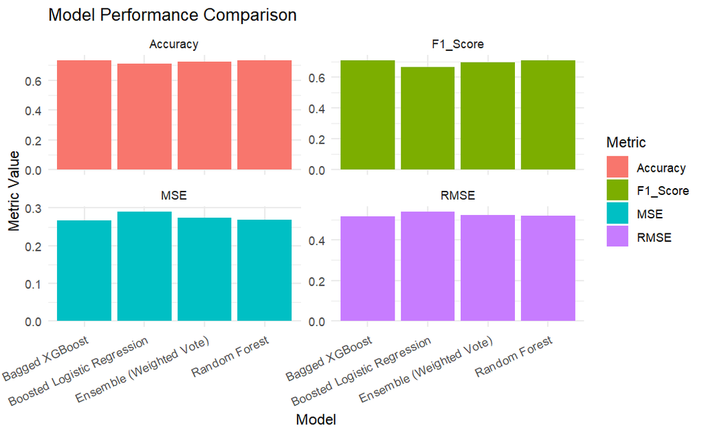

```r
library(tidyverse)

# Data frame
metrics_df <- tribble(
  ~Model, ~Accuracy, ~F1_Score, ~MSE, ~RMSE,
  "Boosted Logistic Regression", 0.7103045, 0.6664918, 0.2896955, 0.5382337,
  "Random Forest", 0.7313388, 0.7083265, 0.2686612, 0.5183254,
  "Bagged XGBoost", 0.7325537, 0.7095976, 0.2674463, 0.5171521,
  "Ensemble (Weighted Vote)", 0.7259473, 0.6957768, 0.2740527, 0.5235004
)

# Convert to long format
metrics_long <- metrics_df %>%
  pivot_longer(cols = -Model, names_to = "Metric", values_to = "Value")

# Plot
ggplot(metrics_long, aes(x = Model, y = Value, fill = Metric)) +
  geom_col(position = position_dodge(width = 0.7)) +
  facet_wrap(~Metric, scales = "free_y") +
  theme_minimal() +
  theme(axis.text.x = element_text(angle = 25, hjust = 1)) +
  labs(title = "Model Performance Comparison", y = "Metric Value", x = "Model")
```

# Original unshaped data metrics

```r
url <- "https://raw.githubusercontent.com/varshithasaval/cardio-vasular-dataset/refs/heads/main/cardio_train.csv"

data <- read.csv(url, sep = ";")
unshaped_df <- data

# outliers

cols <- c("age", "height", "weight", "ap_hi", "ap_lo")

# Function to count outliers
count_outliers <- function(df, cols) {
  z <- scale(df[, cols])
  sapply(as.data.frame(z), function(x) sum(abs(x) > 3))
}

# Check outliers before any removal
outliers_before <- count_outliers(unshaped_df, cols)

# Assuming df_imputed is your data frame
repeat {
  z <- scale(unshaped_df[, cols])  # Scale the data
  out_rows <- apply(abs(z) > 3, 1, any)  # Identify outliers

  # Check if out_rows is all FALSE or NA
  if (all(!out_rows, na.rm = TRUE)) break  # Stop if no more outliers

  unshaped_df <- unshaped_df[!out_rows, ]  # Remove outlier rows
}

# Check outliers after removal
outliers_after <- count_outliers(unshaped_df, cols)

# Data splitting

set.seed(123)

# Split data into training and testing sets (80% training, 20% testing)
sample_index <- sample(1:nrow(unshaped_df), 0.8 * nrow(unshaped_df), replace = FALSE)  # Added closing parenthesis

# Create training and testing sets
train_set <- unshaped_df[sample_index, ]
test_set <- unshaped_df[-sample_index, ]

# Logistic Regression with 5-fold cross-validation

log_training_set <- train_set
log_testing_set <- test_set

# Ensure target is a factor
log_training_set$cardio <- factor(log_training_set$cardio, levels = c(0, 1), labels = c("No", "Yes"))
log_testing_set$cardio <- factor(log_testing_set$cardio, levels = c(0, 1), labels = c("No", "Yes"))

log_model <- train(factor(cardio) ~ .,
                   data = log_training_set,
                   method = "glm",
                   family = "binomial",
                   trControl = trainControl(method = "cv", number = 5, classProbs = TRUE, summaryFunction = twoClassSummary),
                   metric = "ROC"
)

# BOOSTED LOGISTIC REGRESSION (LogitBoost)

set.seed(123)
boosted_log_model <- train(
  cardio ~ .,
  data = log_training_set,
  method = "LogitBoost",
  trControl = trainControl(method = "cv", number = 5, classProbs = TRUE, summaryFunction = twoClassSummary),
  metric = "ROC",
  tuneLength = 10
)

boosted_log_preds <- predict(boosted_log_model, newdata = log_testing_set)
boosted_log_probs <- predict(boosted_log_model, newdata = log_testing_set, type = "prob")[, "Yes"]

cm_log <- confusionMatrix(boosted_log_preds, log_testing_set$cardio)

# random forest

rf_training_set <- train_set
rf_testing_set <- test_set

# Ensure target is a factor
rf_training_set$cardio <- factor(rf_training_set$cardio, levels = c(0, 1), labels = c("No", "Yes"))
rf_testing_set$cardio <- factor(rf_testing_set$cardio, levels = c(0, 1), labels = c("No", "Yes"))

# Preprocessing
preProc <- preProcess(rf_training_set, method = c("center", "scale"))
train_scaled <- predict(preProc, rf_training_set)
test_scaled <- predict(preProc, rf_testing_set)

# Hyperparameter tuning grid
rf_grid <- expand.grid(mtry = c(2, 3, 4))

# Train Random Forest with CV
set.seed(123)
rf_model <- train(
  cardio ~ .,
  data = train_scaled,
  method = "rf",
  trControl = trainControl(method = "cv", number = 5, classProbs = TRUE, summaryFunction = twoClassSummary),
  metric = "ROC",
  tuneGrid = rf_grid,
  ntree = 300
)

# Predictions
rf_predictions <- predict(rf_model, newdata = test_scaled)
rf_probs <- predict(rf_model, newdata = test_scaled, type = "prob")[, "Yes"]

# Evaluation
cm_rf <- confusionMatrix(rf_predictions, test_scaled$cardio)

# XGboost


# Set number of bagging iterations
n_bags <- 10
set.seed(123)

# Prepare storage for predictions
bagged_preds <- matrix(NA, nrow = nrow(test_set), ncol = n_bags)

test_matrix <- model.matrix(cardio ~ ., data = test_set)


for (i in 1:n_bags) {
  # Bootstrap sample
  boot_idx <- sample(1:nrow(train_set), replace = TRUE)
  boot_train <- train_set[boot_idx, ]
  boot_label <- ifelse(train_scaled$cardio[boot_idx] == "Yes", 1, 0)

  # Create DMatrix for this bootstrap
  boot_matrix <- model.matrix(cardio ~ ., data = boot_train)
  dtrain_boot <- xgb.DMatrix(data = boot_matrix, label = boot_label)

  # Train model
  model <- xgboost(data = dtrain_boot,
                   objective = "binary:logistic",
                   nrounds = 100,
                   eta = 0.1,
                   max_depth = 3,
                   verbose = 0)

  # Predict on the test set
  bagged_preds[, i] <- predict(model, newdata = test_matrix)
}

# Average predictions and convert to class labels
final_probs <- rowMeans(bagged_preds)
final_preds <- ifelse(final_probs > 0.5, "Yes", "No")
final_preds <- factor(final_preds, levels = c("No", "Yes"))

# Evaluate
cm_xg <- confusionMatrix(final_preds, test_scaled$cardio)


# Accuracies
boosted_log_accuracy <- cm_log$overall["Accuracy"]
rf_accuracy <- cm_rf$overall["Accuracy"]
xgb_accuracy <- cm_xg$overall["Accuracy"]

# Weighted probabilities
weights <- c(boosted_log_accuracy, rf_accuracy, xgb_accuracy)
weights <- weights / sum(weights)

final_prob <- (weights[1] * boosted_log_probs) +
              (weights[2] * rf_probs) +
              (weights[3] * final_probs)

# Ensemble predictions
final_preds_ensemble <- ifelse(final_prob > 0.5, "Yes", "No")
final_preds_ensemble <- factor(final_preds_ensemble, levels = c("No", "Yes"))

# Confusion matrix
cm_ensemble <- confusionMatrix(final_preds_ensemble, test_scaled$cardio)

# F1 Score
ensemble_f1 <- F1_Score(y_pred = final_preds_ensemble, y_true = test_scaled$cardio, positive = "Yes")

# MSE and RMSE
ensemble_mse <- mean((as.numeric(final_preds_ensemble) - as.numeric(test_scaled$cardio))^2)
ensemble_rmse <- sqrt(ensemble_mse)


# Metrics table
ensemble_metrics <- data.frame(
  Model = "Ensemble (Weighted Vote)",
  Accuracy = cm_ensemble$overall["Accuracy"],
  F1_Score = ensemble_f1,
  MSE = ensemble_mse,
  RMSE = ensemble_rmse
)
```

# Original data Metrics

```r
# F1 scores
f1_log <- F1_Score(y_pred = boosted_log_preds, y_true = log_testing_set$cardio, positive = "Yes")
f1_rf <- F1_Score(y_pred = rf_predictions, y_true = test_scaled$cardio, positive = "Yes")
f1_xg <- F1_Score(y_pred = final_preds, y_true = test_scaled$cardio, positive = "Yes")
f1_ensemble <- F1_Score(y_pred = final_preds_ensemble, y_true = test_scaled$cardio, positive = "Yes")

# MSE & RMSE
mse_log <- mean((as.numeric(boosted_log_preds) - as.numeric(log_testing_set$cardio))^2)
rmse_log <- sqrt(mse_log)

mse_rf <- mean((as.numeric(rf_predictions) - as.numeric(test_scaled$cardio))^2)
rmse_rf <- sqrt(mse_rf)

mse_xg <- mean((as.numeric(final_preds) - as.numeric(test_scaled$cardio))^2)
rmse_xg <- sqrt(mse_xg)

mse_ensemble <- mean((as.numeric(final_preds_ensemble) - as.numeric(test_scaled$cardio))^2)
rmse_ensemble <- sqrt(mse_ensemble)

# Confusion matrices for additional metrics
cm_log <- confusionMatrix(boosted_log_preds, log_testing_set$cardio)
cm_rf <- confusionMatrix(rf_predictions, test_scaled$cardio)
cm_xg <- confusionMatrix(final_preds, test_scaled$cardio)
cm_ensemble <- confusionMatrix(final_preds_ensemble, test_scaled$cardio)

# Extract metrics from confusion matrices
accuracy_log <- cm_log$overall["Accuracy"]
accuracy_rf <- cm_rf$overall["Accuracy"]
accuracy_xg <- cm_xg$overall["Accuracy"]
accuracy_ensemble <- cm_ensemble$overall["Accuracy"]

sensitivity_log <- cm_log$byClass["Sensitivity"]
sensitivity_rf <- cm_rf$byClass["Sensitivity"]
sensitivity_xg <- cm_xg$byClass["Sensitivity"]
sensitivity_ensemble <- cm_ensemble$byClass["Sensitivity"]

specificity_log <- cm_log$byClass["Specificity"]
specificity_rf <- cm_rf$byClass["Specificity"]
specificity_xg <- cm_xg$byClass["Specificity"]
specificity_ensemble <- cm_ensemble$byClass["Specificity"]

balanced_accuracy_log <- cm_log$byClass["Balanced Accuracy"]
balanced_accuracy_rf <- cm_rf$byClass["Balanced Accuracy"]
balanced_accuracy_xg <- cm_xg$byClass["Balanced Accuracy"]
balanced_accuracy_ensemble <- cm_ensemble$byClass["Balanced Accuracy"]

# Final combined metrics table
metrics_table <- data.frame(
  Model = c("original Logistic Regression", "original Random Forest", "original Bagged XGBoost", "original Ensemble (Weighted Vote)"),
  Accuracy = c(accuracy_log, accuracy_rf, accuracy_xg, accuracy_ensemble),
  F1_Score = c(f1_log, f1_rf, f1_xg, f1_ensemble),
  MSE = c(mse_log, mse_rf, mse_xg, mse_ensemble),
  RMSE = c(rmse_log, rmse_rf, rmse_xg, rmse_ensemble),
  Sensitivity = c(sensitivity_log, sensitivity_rf, sensitivity_xg, sensitivity_ensemble),
  Specificity = c(specificity_log, specificity_rf, specificity_xg, specificity_ensemble),
  Balanced_Accuracy = c(balanced_accuracy_log, balanced_accuracy_rf, balanced_accuracy_xg, balanced_accuracy_ensemble)
)

# View the table
knitr::kable(metrics_table)
```

| Model | Accuracy | F1_Score | MSE | RMSE | Sensitivity | Specificity | Balanced_Accuracy |
| --- | --- | --- | --- | --- | --- | --- | --- |
| original Logistic Regression | 0.7143508 | 0.6688392 | 0.2856492 | 0.5344616 | 0.8273318 | 0.5944888 | 0.7109103 |
| original Random Forest | 0.7327357 | 0.7085336 | 0.2672643 | 0.5169761 | 0.7923554 | 0.6694849 | 0.7309201 |
| original Bagged XGBoost | 0.7369900 | 0.7152024 | 0.2630100 | 0.5128450 | 0.7901417 | 0.6806012 | 0.7353714 |
| original Ensemble (Weighted Vote) | 0.7322039 | 0.7011952 | 0.2677961 | 0.5174902 | 0.8119835 | 0.6475654 | 0.7297744 |

```r
NA
```

# Boosted Logistic Regression

Unshaped Data:

Accuracy: 71.43%, F1-Score: 66.88%, MSE: 0.286, RMSE: 0.534

Sensitivity: 82.73% (best among all), Specificity: 59.45%, Balanced Accuracy: 71.09%

Shaped Data:

Accuracy: 71.03%, F1-Score: 66.65%, RMSE: 0.538

Slight drop across all metrics after shaping.

# Random Forest

Unshaped Data:

Accuracy: 73.27%, F1-Score: 70.85%, MSE: 0.267, RMSE: 0.517

Sensitivity: 79.24%, Specificity: 66.95%, Balanced Accuracy: 73.09%

Shaped Data:

Accuracy: 73.13%, F1-Score: 70.83%, RMSE: 0.518

Metrics stayed almost unchanged, showing high robustness.

# Bagged XGBoost

Unshaped Data:

Accuracy: 73.70% (highest), F1-Score: 71.52% (highest), MSE: 0.263, RMSE: 0.513

Sensitivity: 79.01%, Specificity: 68.06%, Balanced Accuracy: 73.54%

Shaped Data:

Accuracy: 73.26%, F1-Score: 70.96%, RMSE: 0.517

Slight decline, but still top-performing overall.

# Ensemble (Weighted Vote)

Unshaped Data:

Accuracy: 73.22%, F1-Score: 70.12%, MSE: 0.268, RMSE: 0.517

Sensitivity: 81.20%, Specificity: 64.76%, Balanced Accuracy: 72.98%

Shaped Data:

Accuracy: 72.59%, F1-Score: 69.58%, RMSE: 0.524

Performance dropped a bit post-shaping.

# Best Overall Model: Bagged XGBoost (Unshaped Data)

Top Accuracy (73.70%), F1-Score (71.52%), Balanced Accuracy (73.54%)

Best combination of precision, recall, and error control.

Performs best on raw features, leveraging complex patterns without shaping.